# R Notebook

## Initialization

```r
source('misc_functions/functions.R')
```

```r
library(tidyverse)
library(plotly)
library(modelr)
library(mgcv)
```

## Data

The `mcycle` data regard a series of measurements of head acceleration in a simulated motorcycle accident, used to test crash helmets. The observations consist of accelerometer readings taken through time, thus there are only two variables `times`, in milliseconds after impact, and `accel`, measured in g, which can be positive or negative with 0 as a resting state.

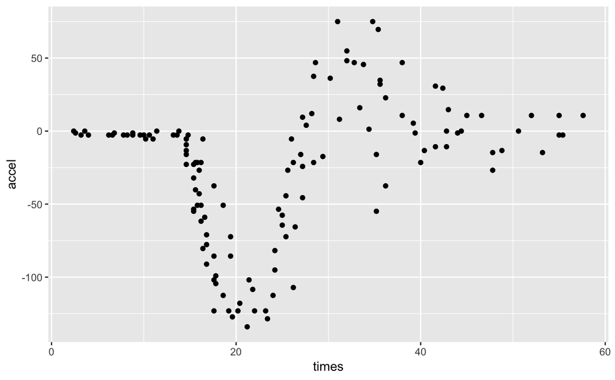

```r
data(mcycle, package = 'MASS')
qplot(data=mcycle, x=times, y=accel)
```

Now fit a regression model of your choosing (e.g. using `lm` `glm` or your favorite package in lieu of `modelfunc`) and plot your predictions against it. If you don’t have any ideas, just use `lm(accel ~ times, data=mcycle)`.

```r
model_start = modelfunc(lm, data = mcycle)

library(modelr)  # install if you don't have
mcycle = mcycle %>%
  add_predictions(model_start, var = 'prediction')

mcycle %>%
  ggplot(aes(times, accel)) +
  geom_point() +
  geom_line(aes(y=prediction))
```

[output not shown]

Now let’s let `ggplot` give us a fit instead.

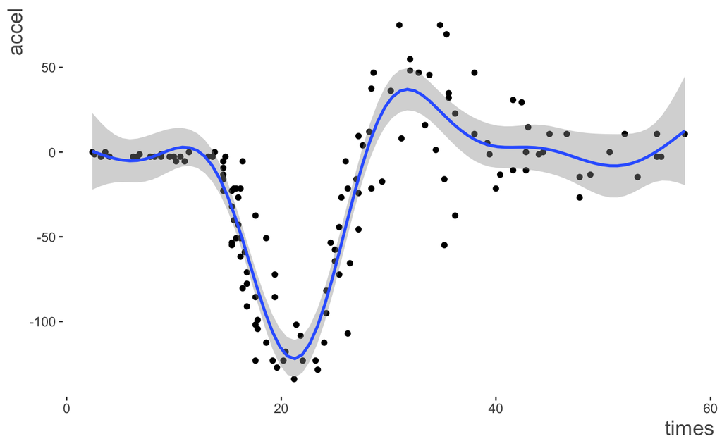

```r
mcycle %>%
  ggplot(aes(times, accel)) +
  geom_point() +
  geom_smooth(method = 'gam', formula = y ~ s(x)) + # the y and x are just generic names for the axes
  theme_trueMinimal()
```

Pretty good! Under the hood we’ve told ggplot to use gam from the mgcv package. The following shows what this might look like had we done it ourselves.

```r
library(mgcv)   # part of base R so you already have it
model_gam = gam(accel ~ s(times), data = mcycle)
summary(model_gam)
```

```
Family: gaussian
Link function: identity

Formula:
accel ~ s(times)

Parametric coefficients:
            Estimate Std. Error t value Pr(>|t|)
(Intercept)  -25.546      1.951   -13.1   <2e-16 ***
---
Signif. codes:  0 ‘***’ 0.001 ‘**’ 0.01 ‘*’ 0.05 ‘.’ 0.1 ‘ ’ 1

Approximate significance of smooth terms:
           edf Ref.df     F p-value
s(times) 8.693  8.972 53.52  <2e-16 ***
---
Signif. codes:  0 ‘***’ 0.001 ‘**’ 0.01 ‘*’ 0.05 ‘.’ 0.1 ‘ ’ 1

R-sq.(adj) =  0.783   Deviance explained = 79.8%
GCV = 545.78  Scale est. = 506       n = 133
```

```r
summary(model_glm)
```

[output not shown]

The syntax is pretty easy, which is great! This means you can more or less jump right in with your current R modeling knowledge. However, know that there are many more possibilities for us in the future.

The output is confusing, but we’ll understand it better later. For now, we can see that the *smooth* term (i.e. `times`) is statistically notable, so we can feel okay about trying to understand its effects. So let’s visualize some predictions.

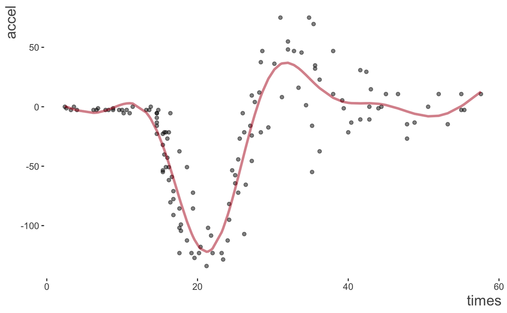

```r
mcycle %>%
  add_predictions(model_gam, var = 'gam_predictions') %>%
  ggplot(aes(times, accel)) +
  geom_point(alpha = .5) +
  geom_line(aes(y = gam_predictions), color = "#b2001d", size = 1.2, alpha = .5) +
  theme_trueMinimal()
```

This clearly isn’t a linear relationship, and it’s not straightforward in general. THAT’S OK! That’s just the way nature is.

In this case, we don’t see any change until about 15 ms, at which point gs go sharply negative, followed by a rebound and eventually settling back to the resting state (though with some oscillation).